# Overview of Some Machine Learning Methods in R

# CART Classification and Regression Trees

#### - Take a predictor x1 and sort the values so that x1[1] is the smallest

#### - Split data into two groups (one group where observations are smaller than x1[1] and one group where observations are bigger than x1[1])

#### - In each group (called a node), classify as A if majority are in group A or classify as B if majority are in group B

#### - Measure “purity” of each split. “Purity” refers to how homogenous the group is. A small value indicates that all objects in a node are the same whereas a large value indicates that the split is more 50-50

#### - Repeat above with x1[2]

#### - Save best x1[i] with best purity

#### - Repeat using x2, x3,….,xi

#### - Stop when purity no longer improves or until each node has nmin observations in it

#### - Purity measured by Gini index

#### - Total purity for a tree is sum of purity of all terminal nodes

#### - Trees are prone to overfitting. Prune to minimize overfitting but watch out for increase in misclassification error

#### - Trees perform better than regression methods if boundaries aren’t linear

```r
library(tree)
icu.cleaned <- read.csv("icu.cleaned.csv", sep = "\t")
set.seed(123)

i.train <- sample(c(TRUE, FALSE), 200, replace = TRUE)
icu.train <- icu.cleaned[i.train, ]
icu.test <- icu.cleaned[-i.train, ]

#Fit a full tree predicting STA (survived or died in ICU)
model.tree <- tree(STA~., data = icu.train)
summary(model.tree)
```

```
##
## Classification tree:
## tree(formula = STA ~ ., data = icu.train)
## Variables actually used in tree construction:
## [1] "LOC"   "sys.c" "SER"   "hra.c" "INF"   "age.c"
## Number of terminal nodes:  10
## Residual mean deviance:  0.5799 = 53.93 / 93
## Misclassification error rate: 0.1456 = 15 / 103
```

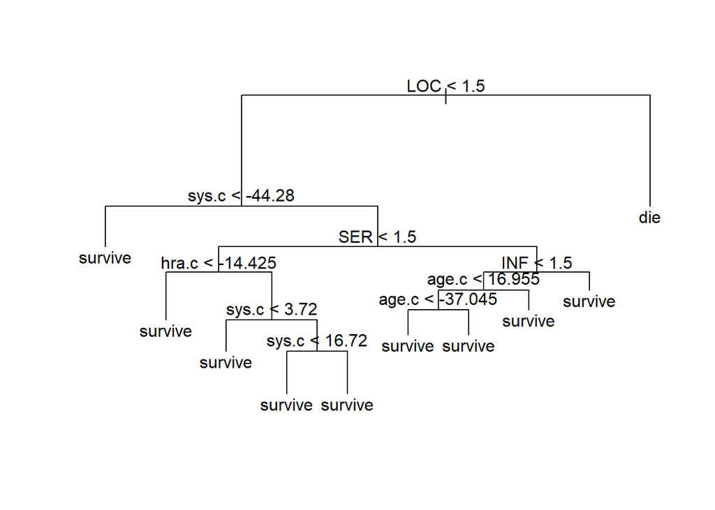

```r
plot(model.tree)
text(model.tree, pretty = TRUE)
```

```r
#Make predictions on testing data
prediction.tree <- predict(model.tree, newdata = icu.test, type = "class")

table(prediction.tree, icu.test$STA)
```

```
##
## prediction.tree die survive
##         die      16       4
##         survive  24     155
```

```r
mean(prediction.tree != icu.test$STA)
```

```
## [1] 0.1407035
```

Our tree has a misclassification rate of 14% (note this is highly variable from tree to tree).

Prune the tree to minimize overfitting

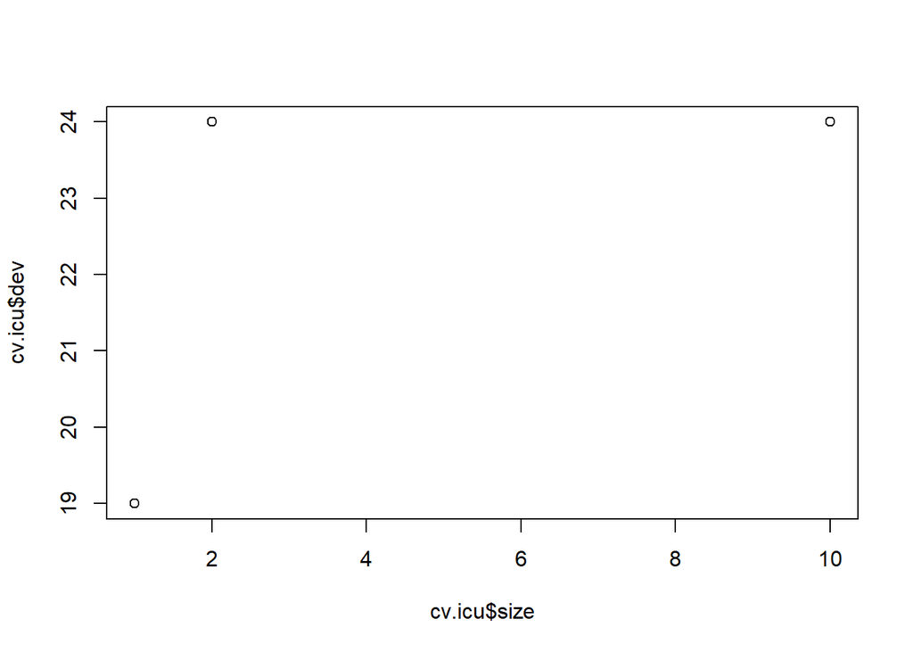

```r
#Cross Validation to determine optimal level of tree complexity
cv.icu <- cv.tree(model.tree, FUN = prune.misclass)
plot(cv.icu$dev ~ cv.icu$size)
```

```r
#best size appears to be 1 (therefore no pruning needed). Command does not work with 1 however so use 2 for this example

pruned.fit <- prune.misclass(model.tree, best = 2)

#Make predictions on testing data
prediction.tree <- predict(pruned.fit, newdata = icu.test, type = "class")
#type = "class" gives us predicted class probabilities. type = "vector" gives us raw probabilities

table(prediction.tree, icu.test$STA)
```

```
##
## prediction.tree die survive
##         die      13       2
##         survive  27     157
```

```r
mean(prediction.tree != icu.test$STA)
```

```
## [1] 0.1457286
```

Test MSE is slightly worse when we use a non-optimal size (2 in this case) ####- Optimal way of going about this is restricting variability of trees in order to improve test MSE, without lowering bias ####- Solution: use bootstrapping (implemented through bagging)

# Bagging

#### - Fit unpruned tree with initial sample

#### - Take a sample of size n (with replacement) from the original sample and fit an unpruned tree

#### - Repeat around 500 times, so you will have 500 trees

#### - For each observation in initial sample, drop it down each of the 500 trees

#### - Each tree will “vote” on the classification of the observation

#### - Majority vote wins

#### - Some observations will be used several times while others may not appear at all

#### - Averaging improves our predictions by decreasing variability while maintaining low bias of a tree

```r
library(randomForest)
set.seed(123)

bagging <- randomForest(STA~., data = icu.cleaned, mtry=19, importance = TRUE)
print(bagging)
```

```
##
## Call:
##  randomForest(formula = STA ~ ., data = icu.cleaned, mtry = 19,      importance = TRUE)
##                Type of random forest: classification
##                      Number of trees: 500
## No. of variables tried at each split: 19
##
##         OOB estimate of  error rate: 16%
## Confusion matrix:
##         die survive class.error
## die      18      22      0.5500
## survive  10     150      0.0625
```

#### - Printing the model provides an estimation of misclassification rate (pretty handy)

#### - Problem with bagging: an influential variable may cause the trees to vote in the same way, causing the trees to be “correlated” (similar to LOOCV)

#### - Solution: use random forests

# Random Forests

#### - How is this different from the above?

#### - When splitting the nodes, instead of going through all possible splits for all possible variables, go through all possible splits on a random sample of a small number of variables m, where m < p

#### - Bagging is where m = p

#### - This works because variables that are strongly correlated will get a chance to appear by themselves without other potentially correlated variables

#### - Final product is a black box which means it is hard to interpret the model

```r
model.rf <- randomForest(STA~., data = icu.cleaned, mtry = 4, importance = TRUE) #mtry specifies the number of variables to use.
#importance specifies whether or not to calculate the relative importance of each variable used (will slow down the model)
print(model.rf)
```

```
##
## Call:
##  randomForest(formula = STA ~ ., data = icu.cleaned, mtry = 4,      importance = TRUE)
##                Type of random forest: classification
##                      Number of trees: 500
## No. of variables tried at each split: 4
##
##         OOB estimate of  error rate: 15%
## Confusion matrix:
##         die survive class.error
## die      16      24      0.6000
## survive   6     154      0.0375
```

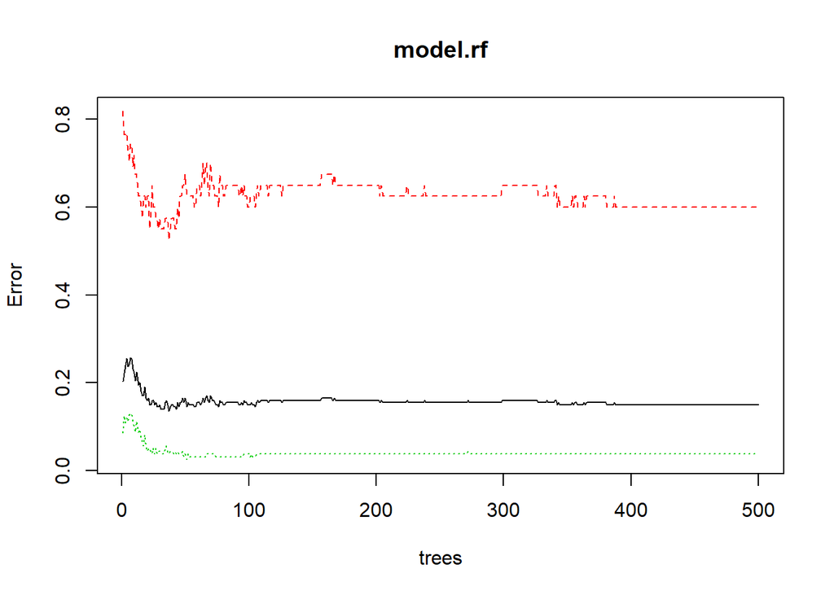

```r
#Plot
plot(model.rf)
```

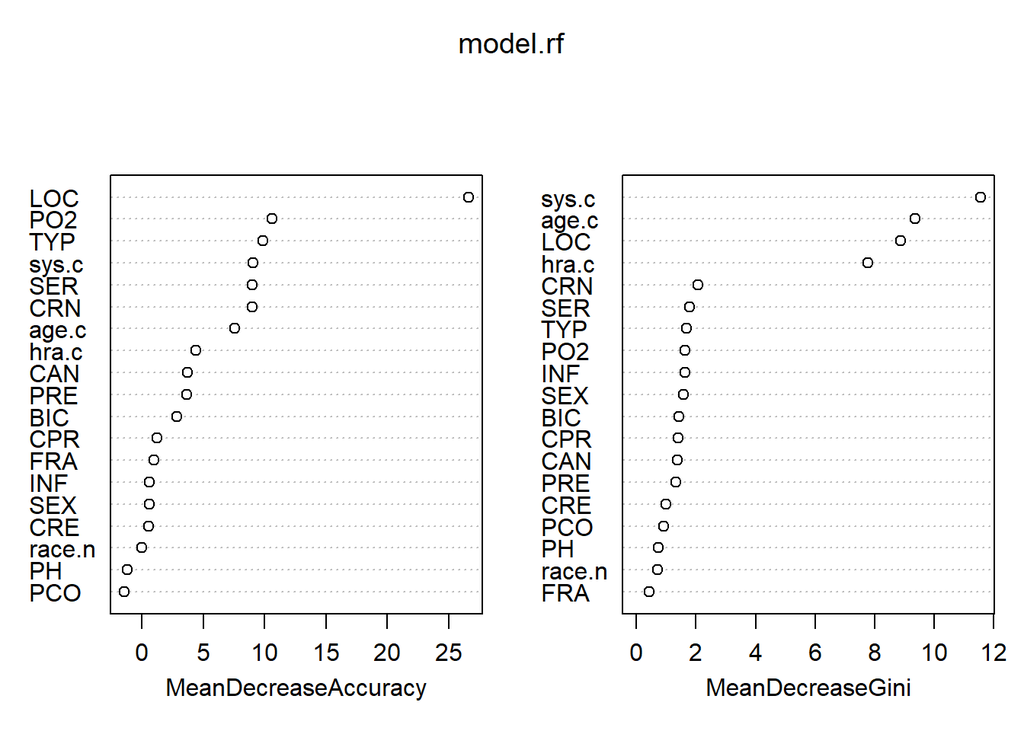

```r
#Variable importance
varImpPlot(model.rf)
```

#### - Fine tuning for random forests

```r
forest2 <- randomForest(STA~.,data=icu.cleaned,mtry=4,cutoff=c(.4,.6))
forest2
```

```
##
## Call:
##  randomForest(formula = STA ~ ., data = icu.cleaned, mtry = 4,      cutoff = c(0.4, 0.6))
##                Type of random forest: classification
##                      Number of trees: 500
## No. of variables tried at each split: 4
##
##         OOB estimate of  error rate: 18%
## Confusion matrix:
##         die survive class.error
## die      17      23     0.57500
## survive  13     147     0.08125
```

```r
#Change the cutoff for tree to vote on whether a patient "dies" to 40%
#So if atleast 40% of trees vote die, then we classify as die


forest3 <- randomForest(STA~.,data=icu.cleaned,mtry=4,sampsize=c(40,100))
#Change the sample size in boostrap and control it by outcome category
#In our data, 40 die and 160 survive
#By setting to c(40, 100), we are getting a greater percentage from "die" on average
#Can also take in a single integer argument
```

# Boosting

#### - An improvement over bagging

#### - Still grow multiple trees, except each subsequent tree depends on the previous tree using “slow learning”

#### - Next tree is created with the residuals (leftover information that could not be explained) of the previous tree

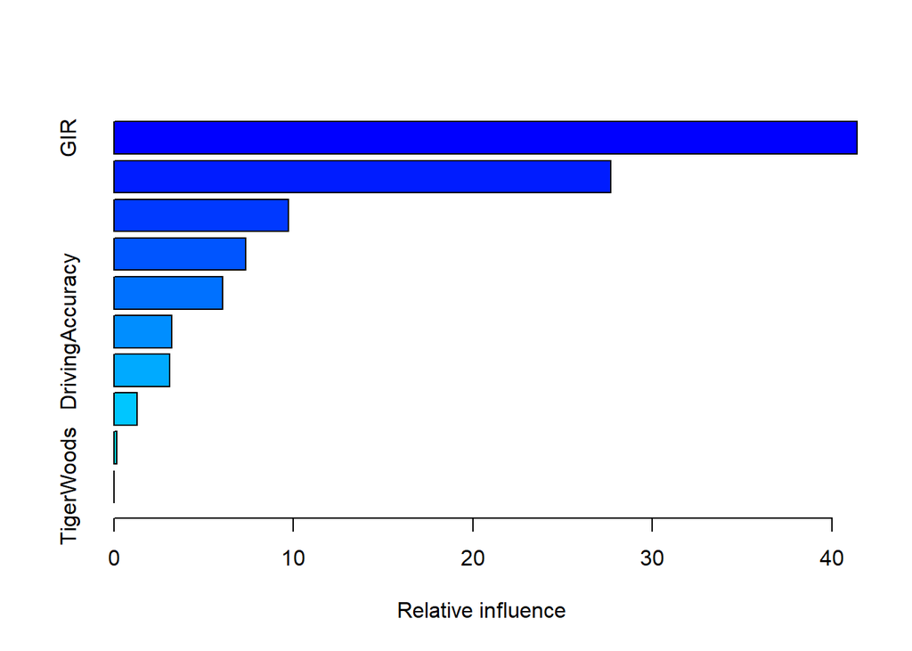

```
##                                   var    rel.inf
## GIR                               GIR 41.4107222
## BirdieConversion     BirdieConversion 27.6710939
## PuttingAverage         PuttingAverage  9.7300004
## BounceBack                 BounceBack  7.3330594
## Scrambling                 Scrambling  6.0551798
## DrivingAccuracy       DrivingAccuracy  3.2315275
## SandSaves                   SandSaves  3.1203570
## PuttsPerRound           PuttsPerRound  1.2955085
## AveDrivingDistance AveDrivingDistance  0.1525512
## TigerWoods                 TigerWoods  0.0000000
```

```r
library(gbm)
library(dplyr)
set.seed(123)
pgatour2006 <- read.csv("pgatour2006.csv")


pga <- mutate(pgatour2006,lprize = log(PrizeMoney)) %>%
select(TigerWoods, AveDrivingDistance:lprize)

fit.gbm <- gbm(lprize~.,data=pga,
interaction.depth=2,n.trees=500,shrinkage=.001,
distribution="gaussian")
summary(fit.gbm)
```

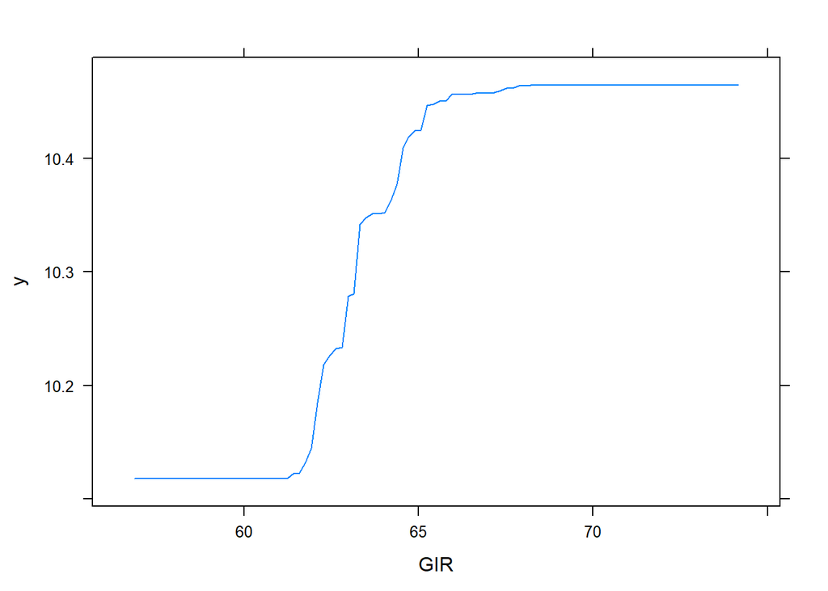

```r
#rel.inf gives the relative influence of each variable (higher value means higher influence)

plot(fit.gbm, i.var = "GIR")
```

```r
#We see that GIR is very important in the range of 62 - 65
```

# Support Vector Machines

#### - Choose a boundary so that the margin between the two groups of points is as large as possible

#### - Based on kernels that control the shape of the classifying boundary

#### - Can set parameters to use a linear kernel or radial kernel

#### - Radial kernels require gamma parameter. A large value of gamma is less flexible and a small value of gamma is more flexible

#### - Linear kernels require the degree of the polynomial

```r
library(e1071)
set.seed(123)

#SVM model
svmfit <- svm(STA~.,data=icu.train,kernel="radial", gamma=1)

#Calculate predictions using test data
prediction.svmfit <- predict(svmfit,newdata=icu.test)
table(prediction.svmfit,icu.test$STA)
```

```
##
## prediction.svmfit die survive
##           die      19       0
##           survive  21     159
```

```r
mean(prediction.svmfit != icu.test$STA)
```

```
## [1] 0.1055276
```

```r
#Tune the model
tune.out <- tune(svm,STA~.,data=icu.train,kernel="radial", ranges=list(cost=c(.1,1,10,100,1000), gamma=c(0.4,1,2,3,4)))
tune.out$best.parameters
```

```
##   cost gamma
## 8   10     1
```

```r
#Predictions with best-tuned model
prediction.best <- predict(tune.out$best.model,newdata=icu.test)
table(prediction.best,icu.test$STA)
```

```
##
## prediction.best die survive
##         die      19       0
##         survive  21     159
```

# Splines

#### - A class of very flexible, non-linear models

#### - Created by a combination of polynomial regression (global) and step functions (local)

#### - Increase flexibility in the hopes of reducing bias enough to improve testing MSE

#### - Regression splines (linear, cubic, natural) and Smoothing splines

#### - Degree splines are constrained to be continuous and smooth (aka first and second derivatives exist), but can have very high variability at the outer ranges

#### - Natural splines solve this problem while maintaining everything previous by adding linear constraints at the outer ranges

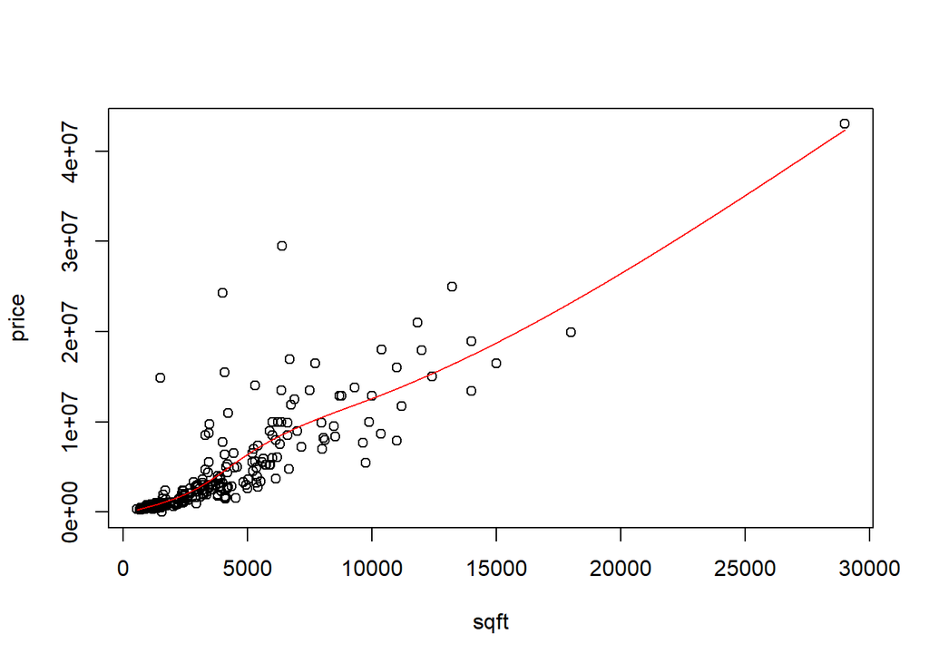

```r
library(splines)

re2 <- read.csv("realestate.csv")

#Fit the spline with 3 knots
ns.fit=lm(price~ns(sqft,knots=c(3000,5000,10000)),data=re2)

minimum <- min(re2$sqft, na.rm = T)
maximum <- max(re2$sqft, na.rm = T)
sqft.grid <- seq(minimum,maximum)

pred=predict(ns.fit,newdata=list(sqft=sqft.grid),se=T)

plot(price~sqft,data=re2)

lines(sqft.grid,pred$fit, col="red")
```